# Course Project 2

Jack Zhan

February 3, 2018

# R Programming (JHU) Coursera

## 02/04/2018

```r
library(data.table)
```

```r
library(ggplot2)
```

## Project Assignment

The basic goal of this assignment is to explore the NOAA Storm Database  
and answer some basic questions about severe weather events. You must  
use the database to answer the questions below and show the code for  
your entire analysis. Your analysis can consist of tables, figures,  
or other summaries. You may use any R package you want to support your  
analysis.

## Project Synopsis

Storms and other severe weather events can cause both public health and  
economic problems for communities and municipalities. Many severe events  
can result in fatalities, injuries, and property damage, and preventing  
such outcomes to the extent possible is a key concern.

This project involves exploring the U.S. National Oceanic and Atmospheric  
Administration’s (NOAA) storm database. This database tracks characteristics  
of major storms and weather events in the United States, including when and  
where they occur, as well as estimates of any fatalities, injuries, and property damage.

# This analysis will address the following questions:

1. Across the United States, which types of events (as indicated in the  
   EVTYPE variable) are most harmful with respect to population health ?
2. Across the United States, which types of events have the greatest  
   economic consequences ?

# This analysis shows by aggregating the data by storm events type :

1. Tornados are the most harmfull events on population health (including  
   injury and fatalities).
2. Floods are responsible for the most economic damage.

## Data Processing

Load and subset the data

```r
getwd()
```

```
## [1] "C:/git/datasciencecoursera/05_Reproducible_Research/Programming_Assignment/Assignment2"
```

```r
dat <- fread("../../Dataset/repdata%2Fdata%2FStormData.csv")
```

[output not shown]

```r
sub_dat <- dat[,c('EVTYPE','FATALITIES','INJURIES', 'PROPDMG', 'PROPDMGEXP', 'CROPDMG', 'CROPDMGEXP')]
```

## Standarize the units in Data Set

```r
sub_dat$PROPDMGNUM = 0
sub_dat[sub_dat$PROPDMGEXP == "H", 'PROPDMGNUM'] = sub_dat[sub_dat$PROPDMGEXP == "H", 'PROPDMG'] * 10^2
sub_dat[sub_dat$PROPDMGEXP == "K", 'PROPDMGNUM'] = sub_dat[sub_dat$PROPDMGEXP == "K", 'PROPDMG'] * 10^3
sub_dat[sub_dat$PROPDMGEXP == "M", 'PROPDMGNUM'] = sub_dat[sub_dat$PROPDMGEXP == "M", 'PROPDMG'] * 10^6
sub_dat[sub_dat$PROPDMGEXP == "B", 'PROPDMGNUM'] = sub_dat[sub_dat$PROPDMGEXP == "B", 'PROPDMG'] * 10^9

sub_dat$CROPDMGNUM = 0
sub_dat[sub_dat$CROPDMGEXP == "H", 'CROPDMGNUM'] = sub_dat[sub_dat$CROPDMGEXP == "H", 'CROPDMG'] * 10^2
sub_dat[sub_dat$CROPDMGEXP == "K", 'CROPDMGNUM'] = sub_dat[sub_dat$CROPDMGEXP == "K", 'CROPDMG'] * 10^3
sub_dat[sub_dat$CROPDMGEXP == "M", 'CROPDMGNUM'] = sub_dat[sub_dat$CROPDMGEXP == "M", 'CROPDMG'] * 10^6
sub_dat[sub_dat$CROPDMGEXP == "B", 'CROPDMGNUM'] = sub_dat[sub_dat$CROPDMGEXP == "B", 'CROPDMG'] * 10^9
```

## Examining the most Harmful Weather Event

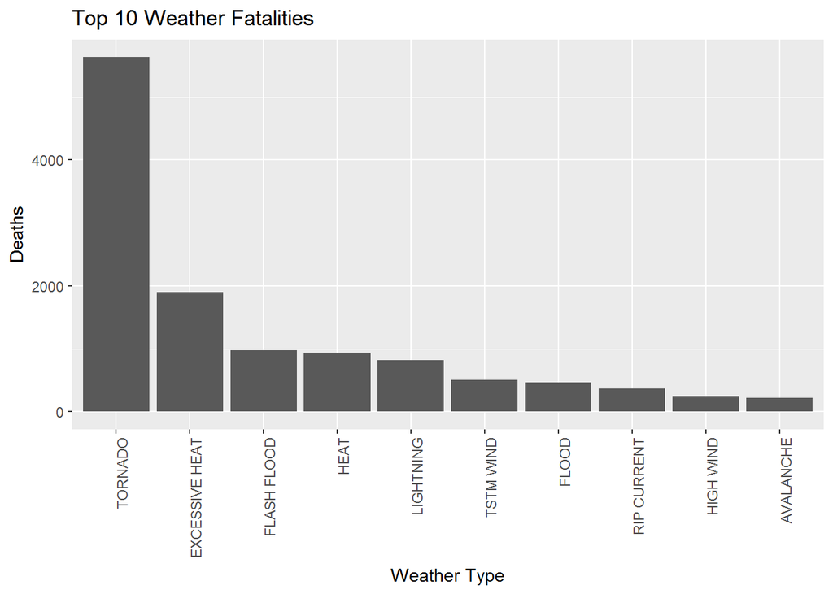

```r
# Plot Weather Event vs number of Fatalities
fatalities <- aggregate(FATALITIES ~ EVTYPE, data=sub_dat, sum)
fatalities <- fatalities[order(-fatalities$FATALITIES), ][1:10, ]
fatalities$EVTYPE <- factor(fatalities$EVTYPE, levels = fatalities$EVTYPE)

ggplot(fatalities, aes(x = EVTYPE, y = FATALITIES)) +
    geom_bar(stat = "identity") +
    theme(axis.text.x = element_text(angle = 90, hjust = 1)) +
    xlab("Weather Type") + ylab("Deaths") + ggtitle("Top 10 Weather Fatalities")
```

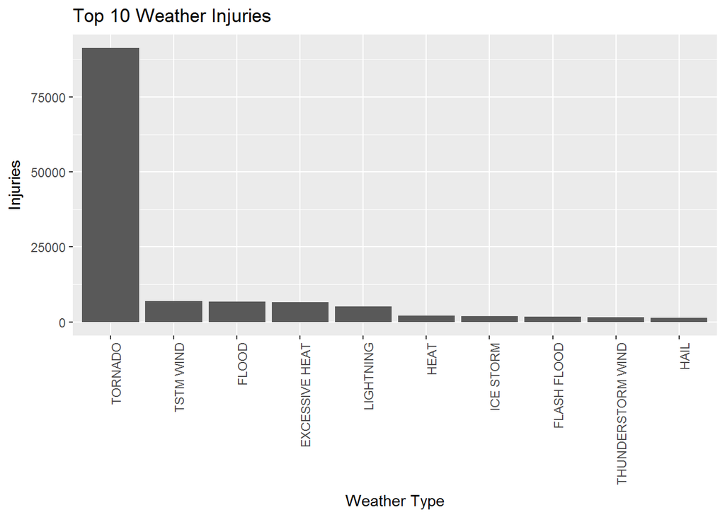

```r
# Plot Weather Event vs number of Injuries
injuries <- aggregate(INJURIES ~ EVTYPE, data=sub_dat, sum)
injuries <- injuries[order(-injuries$INJURIES), ][1:10, ]
injuries$EVTYPE <- factor(injuries$EVTYPE, levels = injuries$EVTYPE)

ggplot(injuries, aes(x = EVTYPE, y = INJURIES)) +
    geom_bar(stat = "identity") +
    theme(axis.text.x = element_text(angle = 90, hjust = 1)) +
    xlab("Weather Type") + ylab("Injuries") + ggtitle("Top 10 Weather Injuries")
```

## Examining the Weather Event that causes the Most Property Damage

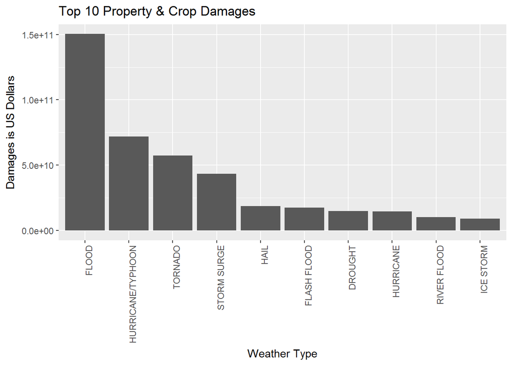

```r
damages <- aggregate(PROPDMGNUM + CROPDMGNUM ~ EVTYPE, data=sub_dat, sum)
names(damages) = c("EVTYPE", "TOTALDAMAGE")
damages <- damages[order(-damages$TOTALDAMAGE), ][1:10, ]
damages$EVTYPE <- factor(damages$EVTYPE, levels = damages$EVTYPE)

ggplot(damages, aes(x = EVTYPE, y = TOTALDAMAGE)) +
    geom_bar(stat = "identity") +
    theme(axis.text.x = element_text(angle = 90, hjust = 1)) +
    xlab("Weather Type") + ylab("Damages is US Dollars") + ggtitle("Top 10 Property & Crop Damages")
```